# 1 Ciencia y tecnología

**En 2023, Castilla-La Mancha destinó un total de 332,8 millones de euros a gastos en I+D interna**

Esta cifra representa apenas un 1,49% del total nacional (22.379 millones de euros). La distribución sectorial muestra que el mayor esfuerzo regional se concentra en el sector empresarial, que absorbe el 57,1% del gasto, seguido por la enseñanza superior (27,4%) y las administraciones públicas (15,3%).

En cuanto al personal dedicado a I+D, Castilla-La Mancha cuenta con 3.943 EJC y el número de mujeres investigadoras en la región es de 2.217, lo que supone un 1,9% del total nacional (115.204).

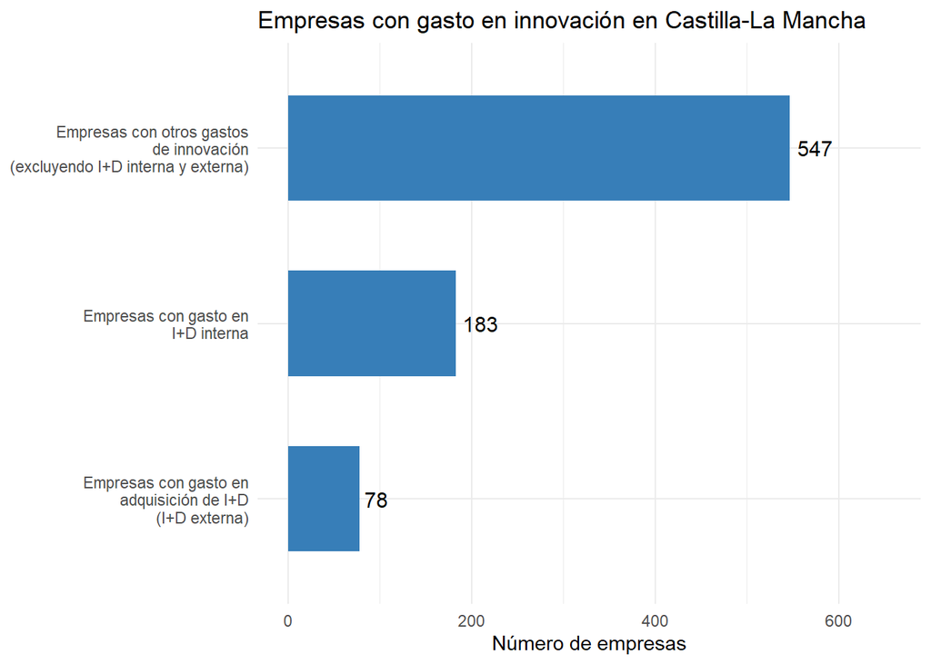

Empresas con gasto en innovación en Castilla-La Mancha

[figure not shown]

Para Julián:

**Tono objetivo y profesional**

Castilla-La Mancha se sitúa por debajo de la media nacional en telefonía fija, móviles, banda ancha y TV de pago.

Guadalajara lidera en conectividad en CLM: más telefonía fija, banda ancha y TV de pago.

Albacete y Cuenca, las provincias con menor penetración en la mayoría de servicios.

La brecha digital persiste: CLM registra menos líneas y abonados que la media de España en todos los servicios analizados.

TELECO (LINEAS POR CADA 100 HABITANTES)

## 1.1 Tono optimista

Castilla-La Mancha avanza en digitalización con más de 98 líneas móviles por cada 100 habitantes.

Guadalajara y Toledo impulsan la conectividad en la región con los mejores datos en banda ancha y telefonía fija.

Más de 1 de cada 10 castellano-manchegos cuenta con televisión de pago.

La telefonía fija sigue siendo un servicio presente en CLM con 31 líneas por cada 100 habitantes.

La región mantiene un crecimiento sostenido en servicios de telecomunicaciones, aunque con margen para seguir acercándose a la media nacional.

[figure not shown]

TIC PC T1

**En 2024, el 55,8% del personal en Castilla-La Mancha utiliza ordenadores con fines empresariales, frente al 68,4% en España**

El uso de ordenadores en CLM alcanza el 47,4% en industria, 42,8% en construcción y 68,2% en servicios, cifras inferiores a las de España (60,1%, 52,9% y 73,4% respectivamente)

TIC PC T2

En 2024, el 8,5% de las empresas de Castilla-La Mancha cuenta con especialistas en TIC, siendo la industria la que más apuesta por ellos (12,2%).

Mientras que en la construcción solo el 3,7% de las empresas emplea especialistas en TIC, en los servicios la cifra asciende al 7,7%.

TIC PC T3

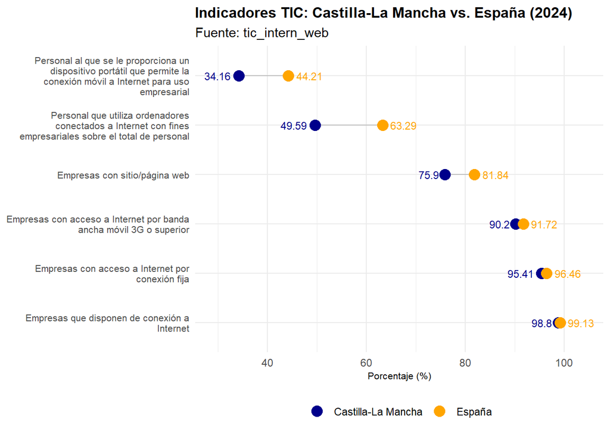

opción 2

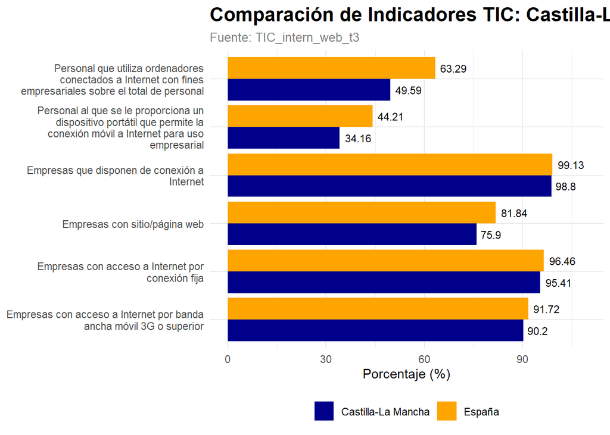

**La conexión a Internet alcanza a casi el 99% de las empresas en Castilla-La Mancha**

Solo un 49,6% del personal en empresas de CLM utiliza ordenadores conectados a Internet

Las empresas de CLM tienen 6 puntos porcentuales menos de página web que la media nacional

En CLM, la provisión de dispositivos portátiles a empleados se sitúa en el 34,16%

Más del 95% de las empresas de Castilla-La Mancha cuentan con acceso fijo a Internet

En el sector de la Construcción de CLM, un 96,69% de las empresas tienen acceso a Internet por banda ancha móvil

TIC Teletrabajo T4

En Castilla-La Mancha, el 47,44% de las empresas declara llevar a cabo reuniones remotas, mientras que el 24,12% permite a sus empleados realizar teletrabajo. No obstante, únicamente el 5,95% de los trabajadores teletrabaja de manera regular.

TIC medios sociales T5

En 2024, el 54,9% de las empresas de Castilla-La Mancha utiliza medios sociales, frente al 64,7% a nivel nacional, con mayor adopción en el sector servicios

TIC publicidad T6

El 21,4% de las empresas de Castilla-La Mancha invierte en publicidad en Internet, con mayor presencia en el sector servicios (22,97%) y menor en construcción (18,83%)

TIC estadísticas T7

el 21,23% de las empresas de Castilla-La Mancha realiza análisis de datos internamente, con mayor proporción en servicios (24,99%) e industria (23,79%), y mínima participación en construcción (7,52%).

TIC Cloud computing T8

La adquisición de servicios de cloud computing alcanza el 23,48% de las empresas de Castilla-La Mancha, con la adopción más elevada en industria (26,27%) y servicios (25,86%), y la más baja en construcción (12,63%)

TIC IA T9

El 7,63% de las empresas de Castilla-La Mancha emplea tecnologías de inteligencia artificial, frente al 12,38% a nivel nacional, con mayor adopción en el sector servicios (8,86%) y menor en industria (5,71%).

TIC Gasto ciberseguridad e IA T10

En 2024, las empresas de Castilla-La Mancha destinan 59.698 € de media a seguridad TIC, concentrando el mayor gasto en servicios (38.452 €) e industria (19.588 €), mientras que la inversión en sistemas de inteligencia artificial alcanza 8.107 €, concentrada principalmente en industria (7.729 €)

TIC PORCENTAJE DE EMPRESAS CON MENOS DE 10 EMPLEADOS

Indicadores TIC en empresas con menos de 10 empleados (2024)

| Indicador | Castilla-La Mancha | España |
| --- | --- | --- |
| Empresas que disponen de ordenadores | 83.87 | 87.90 |
| Empresas que emplean especialistas en TIC | 0.47 | 1.85 |
| Empresas que disponen de conexión a Internet | 77.83 | 83.81 |
| Empresas con acceso a Internet por conexión fija | 82.40 | 81.20 |
| Empresas con acceso a Internet por banda ancha móvil 3G o superior | 88.04 | 84.96 |
| Empresas con sitio/página web | 28.15 | 33.21 |
| Empresas que utilizan Medios Sociales | 28.18 | 34.58 |
| Empresas que compran servicios de cloud computing | 7.22 | 12.46 |

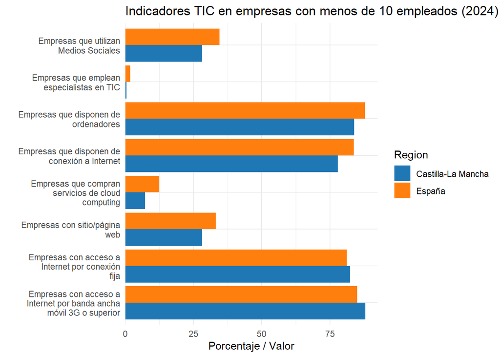